# Risk Factor Analysis

## Outcome Variable

**Outcome Variable:** haz

## Predictor Variables

**Intervention Variable:** single

**Adjustment Set:**

- arm
- W_mage
- meducyrs
- feducyrs
- W_mhtcm
- W_mwtkg
- W_mbmi
- delta_W_mage
- delta_meducyrs
- delta_feducyrs
- delta_W_mhtcm
- delta_W_mwtkg
- delta_W_mbmi

## Stratifying Variables

The analysis was stratified on these variable(s):

- agecat
- studyid
- country

## Data Summary

| agecat | studyid | country | single | n_cell | n |
| --- | --- | --- | --- | --- | --- |
| Birth | ki0047075b-MAL-ED | BANGLADESH | 0 | 231 | 231 |
| Birth | ki0047075b-MAL-ED | BANGLADESH | 1 | 0 | 231 |
| Birth | ki0047075b-MAL-ED | BRAZIL | 0 | 57 | 65 |
| Birth | ki0047075b-MAL-ED | BRAZIL | 1 | 8 | 65 |
| Birth | ki0047075b-MAL-ED | INDIA | 0 | 47 | 47 |
| Birth | ki0047075b-MAL-ED | INDIA | 1 | 0 | 47 |
| Birth | ki0047075b-MAL-ED | NEPAL | 0 | 27 | 27 |
| Birth | ki0047075b-MAL-ED | NEPAL | 1 | 0 | 27 |
| Birth | ki0047075b-MAL-ED | PERU | 0 | 209 | 233 |
| Birth | ki0047075b-MAL-ED | PERU | 1 | 24 | 233 |
| Birth | ki0047075b-MAL-ED | SOUTH AFRICA | 0 | 63 | 123 |
| Birth | ki0047075b-MAL-ED | SOUTH AFRICA | 1 | 60 | 123 |
| Birth | ki0047075b-MAL-ED | TANZANIA, UNITED REPUBLIC OF | 0 | 122 | 125 |
| Birth | ki0047075b-MAL-ED | TANZANIA, UNITED REPUBLIC OF | 1 | 3 | 125 |
| Birth | ki1119695-PROBIT | BELARUS | 0 | 13348 | 13890 |
| Birth | ki1119695-PROBIT | BELARUS | 1 | 542 | 13890 |
| Birth | ki1126311-ZVITAMBO | ZIMBABWE | 0 | 12942 | 13817 |
| Birth | ki1126311-ZVITAMBO | ZIMBABWE | 1 | 875 | 13817 |
| Birth | ki1135781-COHORTS | GUATEMALA | 0 | 719 | 767 |
| Birth | ki1135781-COHORTS | GUATEMALA | 1 | 48 | 767 |
| Birth | ki1135781-COHORTS | INDIA | 0 | 4771 | 4778 |
| Birth | ki1135781-COHORTS | INDIA | 1 | 7 | 4778 |
| Birth | ki1135781-COHORTS | PHILIPPINES | 0 | 2936 | 3010 |
| Birth | ki1135781-COHORTS | PHILIPPINES | 1 | 74 | 3010 |
| Birth | kiGH5241-JiVitA-4 | BANGLADESH | 0 | 2814 | 2819 |
| Birth | kiGH5241-JiVitA-4 | BANGLADESH | 1 | 5 | 2819 |
| 6 months | ki0047075b-MAL-ED | BANGLADESH | 0 | 241 | 241 |
| 6 months | ki0047075b-MAL-ED | BANGLADESH | 1 | 0 | 241 |
| 6 months | ki0047075b-MAL-ED | BRAZIL | 0 | 179 | 209 |
| 6 months | ki0047075b-MAL-ED | BRAZIL | 1 | 30 | 209 |

[output cut: 54 more lines]

The following strata were considered:

- agecat: 24 months, studyid: ki0047075b-MAL-ED, country: BANGLADESH
- agecat: 24 months, studyid: ki0047075b-MAL-ED, country: BRAZIL
- agecat: 24 months, studyid: ki0047075b-MAL-ED, country: INDIA
- agecat: 24 months, studyid: ki0047075b-MAL-ED, country: NEPAL
- agecat: 24 months, studyid: ki0047075b-MAL-ED, country: PERU
- agecat: 24 months, studyid: ki0047075b-MAL-ED, country: SOUTH AFRICA
- agecat: 24 months, studyid: ki0047075b-MAL-ED, country: TANZANIA, UNITED REPUBLIC OF
- agecat: 24 months, studyid: ki1066203-TanzaniaChild2, country: TANZANIA, UNITED REPUBLIC OF
- agecat: 24 months, studyid: ki1119695-PROBIT, country: BELARUS
- agecat: 24 months, studyid: ki1126311-ZVITAMBO, country: ZIMBABWE
- agecat: 24 months, studyid: ki1135781-COHORTS, country: GUATEMALA
- agecat: 24 months, studyid: ki1135781-COHORTS, country: INDIA
- agecat: 24 months, studyid: ki1135781-COHORTS, country: PHILIPPINES
- agecat: 24 months, studyid: kiGH5241-JiVitA-4, country: BANGLADESH
- agecat: 6 months, studyid: ki0047075b-MAL-ED, country: BANGLADESH
- agecat: 6 months, studyid: ki0047075b-MAL-ED, country: BRAZIL
- agecat: 6 months, studyid: ki0047075b-MAL-ED, country: INDIA
- agecat: 6 months, studyid: ki0047075b-MAL-ED, country: NEPAL
- agecat: 6 months, studyid: ki0047075b-MAL-ED, country: PERU
- agecat: 6 months, studyid: ki0047075b-MAL-ED, country: SOUTH AFRICA
- agecat: 6 months, studyid: ki0047075b-MAL-ED, country: TANZANIA, UNITED REPUBLIC OF
- agecat: 6 months, studyid: ki1066203-TanzaniaChild2, country: TANZANIA, UNITED REPUBLIC OF
- agecat: 6 months, studyid: ki1112895-Guatemala BSC, country: GUATEMALA
- agecat: 6 months, studyid: ki1119695-PROBIT, country: BELARUS
- agecat: 6 months, studyid: ki1126311-ZVITAMBO, country: ZIMBABWE
- agecat: 6 months, studyid: ki1135781-COHORTS, country: GUATEMALA
- agecat: 6 months, studyid: ki1135781-COHORTS, country: INDIA
- agecat: 6 months, studyid: ki1135781-COHORTS, country: PHILIPPINES
- agecat: 6 months, studyid: kiGH5241-JiVitA-4, country: BANGLADESH
- agecat: Birth, studyid: ki0047075b-MAL-ED, country: BANGLADESH
- agecat: Birth, studyid: ki0047075b-MAL-ED, country: BRAZIL
- agecat: Birth, studyid: ki0047075b-MAL-ED, country: INDIA
- agecat: Birth, studyid: ki0047075b-MAL-ED, country: NEPAL
- agecat: Birth, studyid: ki0047075b-MAL-ED, country: PERU
- agecat: Birth, studyid: ki0047075b-MAL-ED, country: SOUTH AFRICA
- agecat: Birth, studyid: ki0047075b-MAL-ED, country: TANZANIA, UNITED REPUBLIC OF
- agecat: Birth, studyid: ki1119695-PROBIT, country: BELARUS
- agecat: Birth, studyid: ki1126311-ZVITAMBO, country: ZIMBABWE
- agecat: Birth, studyid: ki1135781-COHORTS, country: GUATEMALA
- agecat: Birth, studyid: ki1135781-COHORTS, country: INDIA
- agecat: Birth, studyid: ki1135781-COHORTS, country: PHILIPPINES
- agecat: Birth, studyid: kiGH5241-JiVitA-4, country: BANGLADESH

### Dropped Strata

Some strata were dropped due to rare outcomes:

- agecat: Birth, studyid: ki0047075b-MAL-ED, country: BANGLADESH
- agecat: Birth, studyid: ki0047075b-MAL-ED, country: INDIA
- agecat: Birth, studyid: ki0047075b-MAL-ED, country: NEPAL
- agecat: Birth, studyid: ki0047075b-MAL-ED, country: TANZANIA, UNITED REPUBLIC OF
- agecat: 6 months, studyid: ki0047075b-MAL-ED, country: BANGLADESH
- agecat: 6 months, studyid: ki0047075b-MAL-ED, country: INDIA
- agecat: 6 months, studyid: ki0047075b-MAL-ED, country: NEPAL
- agecat: 24 months, studyid: ki0047075b-MAL-ED, country: BANGLADESH
- agecat: 24 months, studyid: ki0047075b-MAL-ED, country: INDIA
- agecat: 24 months, studyid: ki0047075b-MAL-ED, country: NEPAL
- agecat: 24 months, studyid: ki1066203-TanzaniaChild2, country: TANZANIA, UNITED REPUBLIC OF

## Methods Detail

We’re interested in the causal parameters $E[Y_a]$ for all values of $a \in \mathcal{A}$. These parameters represent the mean outcome if, possibly contrary to fact, we intervened to set all units to have $A=a$. Under the randomization and positivity assumptions, these are identified by the statistical parameters $\psi_a=E_W[E_{Y|A,W}(Y|A=a,W)]$. In addition, we’re interested in the mean of $Y$, $E[Y]$ under no intervention (the observed mean). We will estimate these parameters by using SuperLearner to fit the relevant likelihood factors – $E_{Y|A,W}(Y|A=a,W)$ and $p(A=a|W)$, and then updating our likelihood fit using a joint TMLE.

For unadjusted analyses ($W=\{\}$), initial likelihoods were estimated using Lrnr_glm to estimate the simple $E(Y|A)$ and Lrnr_mean to estimate $p(A)$. For adjusted analyses, a small library containing Lrnr_glmnet, Lrnr_xgboost, and Lrnr_mean was used.

Having estimated these parameters, we will then use the delta method to estimate relative risks and attributable risks relative to a prespecified baseline level of $A$.

# Results Detail

## Results Plots

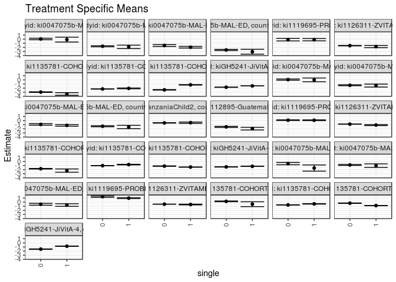

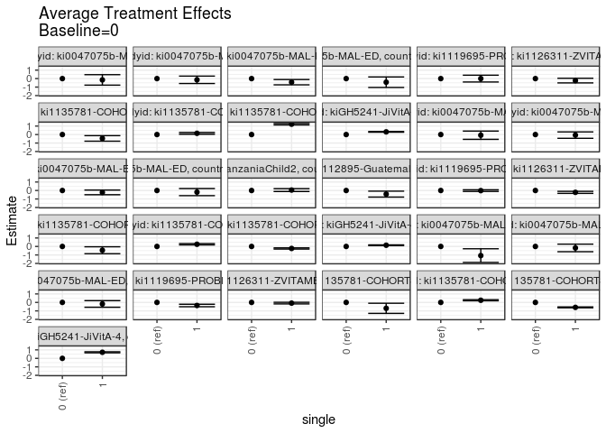

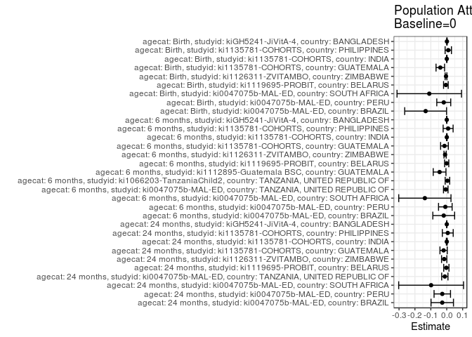

## Results Table

### Parameter: TSM

| agecat | studyid | country | intervention_level | baseline_level | estimate | ci_lower | ci_upper |
| --- | --- | --- | --- | --- | --- | --- | --- |
| Birth | ki0047075b-MAL-ED | BRAZIL | 0 | NA | -0.5433333 | -0.8229128 | -0.2637539 |
| Birth | ki0047075b-MAL-ED | BRAZIL | 1 | NA | -1.6212500 | -2.3756597 | -0.8668403 |
| Birth | ki0047075b-MAL-ED | PERU | 0 | NA | -0.8641307 | -0.9853586 | -0.7429028 |
| Birth | ki0047075b-MAL-ED | PERU | 1 | NA | -1.0368196 | -1.4697387 | -0.6039005 |
| Birth | ki0047075b-MAL-ED | SOUTH AFRICA | 0 | NA | -0.5219213 | -0.7502657 | -0.2935769 |
| Birth | ki0047075b-MAL-ED | SOUTH AFRICA | 1 | NA | -0.7025304 | -1.0182794 | -0.3867813 |
| Birth | ki1119695-PROBIT | BELARUS | 0 | NA | 1.3323383 | 1.1674770 | 1.4971995 |
| Birth | ki1119695-PROBIT | BELARUS | 1 | NA | 0.9681984 | 0.8766431 | 1.0597536 |
| Birth | ki1126311-ZVITAMBO | ZIMBABWE | 0 | NA | -0.4962883 | -0.5175349 | -0.4750418 |
| Birth | ki1126311-ZVITAMBO | ZIMBABWE | 1 | NA | -0.5799120 | -0.6738798 | -0.4859441 |
| Birth | ki1135781-COHORTS | GUATEMALA | 0 | NA | 0.1914946 | 0.1013865 | 0.2816028 |
| Birth | ki1135781-COHORTS | GUATEMALA | 1 | NA | -0.5038772 | -1.0942433 | 0.0864889 |
| Birth | ki1135781-COHORTS | INDIA | 0 | NA | -0.6778139 | -0.7115208 | -0.6441070 |
| Birth | ki1135781-COHORTS | INDIA | 1 | NA | -0.4242857 | -0.4784569 | -0.3701145 |
| Birth | ki1135781-COHORTS | PHILIPPINES | 0 | NA | -0.2563383 | -0.3009430 | -0.2117336 |
| Birth | ki1135781-COHORTS | PHILIPPINES | 1 | NA | -0.8411552 | -0.8739959 | -0.8083145 |
| Birth | kiGH5241-JiVitA-4 | BANGLADESH | 0 | NA | -1.5248721 | -1.5752417 | -1.4745025 |
| Birth | kiGH5241-JiVitA-4 | BANGLADESH | 1 | NA | -0.8080000 | -0.8384743 | -0.7775257 |
| 6 months | ki0047075b-MAL-ED | BRAZIL | 0 | NA | 0.0698371 | -0.0802300 | 0.2199042 |
| 6 months | ki0047075b-MAL-ED | BRAZIL | 1 | NA | -0.0072115 | -0.4710923 | 0.4566693 |
| 6 months | ki0047075b-MAL-ED | PERU | 0 | NA | -1.3192624 | -1.4327029 | -1.2058219 |
| 6 months | ki0047075b-MAL-ED | PERU | 1 | NA | -1.3842474 | -1.7442187 | -1.0242762 |
| 6 months | ki0047075b-MAL-ED | SOUTH AFRICA | 0 | NA | -0.9263631 | -1.1196566 | -0.7330696 |
| 6 months | ki0047075b-MAL-ED | SOUTH AFRICA | 1 | NA | -1.1501727 | -1.3437536 | -0.9565919 |
| 6 months | ki0047075b-MAL-ED | TANZANIA, UNITED REPUBLIC OF | 0 | NA | -1.3626290 | -1.4879351 | -1.2373229 |
| 6 months | ki0047075b-MAL-ED | TANZANIA, UNITED REPUBLIC OF | 1 | NA | -1.5514583 | -1.9539746 | -1.1489420 |
| 6 months | ki1066203-TanzaniaChild2 | TANZANIA, UNITED REPUBLIC OF | 0 | NA | -0.5502680 | -0.6016857 | -0.4988503 |
| 6 months | ki1066203-TanzaniaChild2 | TANZANIA, UNITED REPUBLIC OF | 1 | NA | -0.4983344 | -0.6574670 | -0.3392017 |
| 6 months | ki1112895-Guatemala BSC | GUATEMALA | 0 | NA | -1.5175237 | -1.6397054 | -1.3953420 |
| 6 months | ki1112895-Guatemala BSC | GUATEMALA | 1 | NA | -1.9436216 | -2.2707688 | -1.6164745 |
| 6 months | ki1119695-PROBIT | BELARUS | 0 | NA | 0.1071971 | 0.0128763 | 0.2015179 |
| 6 months | ki1119695-PROBIT | BELARUS | 1 | NA | 0.0929958 | -0.0028893 | 0.1888809 |
| 6 months | ki1126311-ZVITAMBO | ZIMBABWE | 0 | NA | -0.8574418 | -0.8837278 | -0.8311559 |
| 6 months | ki1126311-ZVITAMBO | ZIMBABWE | 1 | NA | -1.0748429 | -1.1923647 | -0.9573211 |
| 6 months | ki1135781-COHORTS | GUATEMALA | 0 | NA | -1.7947503 | -1.8680036 | -1.7214971 |
| 6 months | ki1135781-COHORTS | GUATEMALA | 1 | NA | -2.2417327 | -2.6433894 | -1.8400759 |
| 6 months | ki1135781-COHORTS | INDIA | 0 | NA | -1.0423478 | -1.0757913 | -1.0089044 |
| 6 months | ki1135781-COHORTS | INDIA | 1 | NA | -0.7833333 | -0.8545896 | -0.7120771 |
| 6 months | ki1135781-COHORTS | PHILIPPINES | 0 | NA | -1.1502359 | -1.2042671 | -1.0962048 |
| 6 months | ki1135781-COHORTS | PHILIPPINES | 1 | NA | -1.3868563 | -1.4312957 | -1.3424169 |
| 6 months | kiGH5241-JiVitA-4 | BANGLADESH | 0 | NA | -1.3443862 | -1.3825869 | -1.3061854 |
| 6 months | kiGH5241-JiVitA-4 | BANGLADESH | 1 | NA | -1.1993750 | -1.2225095 | -1.1762405 |
| 24 months | ki0047075b-MAL-ED | BRAZIL | 0 | NA | 0.0353495 | -0.1431845 | 0.2138835 |
| 24 months | ki0047075b-MAL-ED | BRAZIL | 1 | NA | -0.1174004 | -0.7052743 | 0.4704735 |
| 24 months | ki0047075b-MAL-ED | PERU | 0 | NA | -1.7265238 | -1.8508192 | -1.6022284 |
| 24 months | ki0047075b-MAL-ED | PERU | 1 | NA | -1.8689701 | -2.2867062 | -1.4512339 |
| 24 months | ki0047075b-MAL-ED | SOUTH AFRICA | 0 | NA | -1.5509713 | -1.7921971 | -1.3097455 |
| 24 months | ki0047075b-MAL-ED | SOUTH AFRICA | 1 | NA | -1.9718922 | -2.1739461 | -1.7698384 |
| 24 months | ki0047075b-MAL-ED | TANZANIA, UNITED REPUBLIC OF | 0 | NA | -2.6332212 | -2.7707507 | -2.4956916 |
| 24 months | ki0047075b-MAL-ED | TANZANIA, UNITED REPUBLIC OF | 1 | NA | -3.0591667 | -3.6621048 | -2.4562285 |
| 24 months | ki1119695-PROBIT | BELARUS | 0 | NA | -0.1289508 | -0.4353928 | 0.1774912 |
| 24 months | ki1119695-PROBIT | BELARUS | 1 | NA | -0.1273985 | -0.4153751 | 0.1605781 |
| 24 months | ki1126311-ZVITAMBO | ZIMBABWE | 0 | NA | -1.5874612 | -1.6453731 | -1.5295493 |
| 24 months | ki1126311-ZVITAMBO | ZIMBABWE | 1 | NA | -1.8210845 | -2.0895512 | -1.5526177 |
| 24 months | ki1135781-COHORTS | GUATEMALA | 0 | NA | -2.9764049 | -3.0464692 | -2.9063405 |
| 24 months | ki1135781-COHORTS | GUATEMALA | 1 | NA | -3.4307531 | -3.7489358 | -3.1125705 |
| 24 months | ki1135781-COHORTS | INDIA | 0 | NA | -2.2134909 | -2.2535699 | -2.1734120 |
| 24 months | ki1135781-COHORTS | INDIA | 1 | NA | -2.0688889 | -2.1675727 | -1.9702051 |
| 24 months | ki1135781-COHORTS | PHILIPPINES | 0 | NA | -2.4272501 | -2.4858163 | -2.3686839 |
| 24 months | ki1135781-COHORTS | PHILIPPINES | 1 | NA | -1.2043178 | -1.2682418 | -1.1403938 |
| 24 months | kiGH5241-JiVitA-4 | BANGLADESH | 0 | NA | -1.7815365 | -1.8179487 | -1.7451244 |
| 24 months | kiGH5241-JiVitA-4 | BANGLADESH | 1 | NA | -1.4650000 | -1.4755957 | -1.4544043 |

### Parameter: E(Y)

| agecat | studyid | country | intervention_level | baseline_level | estimate | ci_lower | ci_upper |
| --- | --- | --- | --- | --- | --- | --- | --- |
| Birth | ki0047075b-MAL-ED | BRAZIL | NA | NA | -0.6760000 | -0.9521457 | -0.3998543 |
| Birth | ki0047075b-MAL-ED | PERU | NA | NA | -0.8827897 | -1.0001058 | -0.7654736 |
| Birth | ki0047075b-MAL-ED | SOUTH AFRICA | NA | NA | -0.6317073 | -0.8249555 | -0.4384591 |
| Birth | ki1119695-PROBIT | BELARUS | NA | NA | 1.3269446 | 1.1683850 | 1.4855041 |
| Birth | ki1126311-ZVITAMBO | ZIMBABWE | NA | NA | -0.5007838 | -0.5213479 | -0.4802197 |
| Birth | ki1135781-COHORTS | GUATEMALA | NA | NA | 0.1511213 | 0.0632481 | 0.2389944 |
| Birth | ki1135781-COHORTS | INDIA | NA | NA | -0.6774424 | -0.7103357 | -0.6445492 |
| Birth | ki1135781-COHORTS | PHILIPPINES | NA | NA | -0.2465548 | -0.2856502 | -0.2074594 |
| Birth | kiGH5241-JiVitA-4 | BANGLADESH | NA | NA | -1.5236006 | -1.5727441 | -1.4744571 |
| 6 months | ki0047075b-MAL-ED | BRAZIL | NA | NA | 0.0510207 | -0.0930194 | 0.1950608 |
| 6 months | ki0047075b-MAL-ED | PERU | NA | NA | -1.3280952 | -1.4363364 | -1.2198541 |
| 6 months | ki0047075b-MAL-ED | SOUTH AFRICA | NA | NA | -1.0639173 | -1.1916078 | -0.9362269 |
| 6 months | ki0047075b-MAL-ED | TANZANIA, UNITED REPUBLIC OF | NA | NA | -1.3687449 | -1.4907629 | -1.2467270 |
| 6 months | ki1066203-TanzaniaChild2 | TANZANIA, UNITED REPUBLIC OF | NA | NA | -0.5457721 | -0.5948454 | -0.4966988 |
| 6 months | ki1112895-Guatemala BSC | GUATEMALA | NA | NA | -1.5624368 | -1.6783540 | -1.4465196 |
| 6 months | ki1119695-PROBIT | BELARUS | NA | NA | 0.1069986 | 0.0122286 | 0.2017686 |
| 6 months | ki1126311-ZVITAMBO | ZIMBABWE | NA | NA | -0.8677917 | -0.8934036 | -0.8421799 |
| 6 months | ki1135781-COHORTS | GUATEMALA | NA | NA | -1.8089474 | -1.8800645 | -1.7378303 |
| 6 months | ki1135781-COHORTS | INDIA | NA | NA | -1.0418789 | -1.0745363 | -1.0092215 |
| 6 months | ki1135781-COHORTS | PHILIPPINES | NA | NA | -1.1414425 | -1.1836656 | -1.0992193 |
| 6 months | kiGH5241-JiVitA-4 | BANGLADESH | NA | NA | -1.3441456 | -1.3814027 | -1.3068885 |
| 24 months | ki0047075b-MAL-ED | BRAZIL | NA | NA | 0.0071006 | -0.1615817 | 0.1757828 |
| 24 months | ki0047075b-MAL-ED | PERU | NA | NA | -1.7544776 | -1.8753255 | -1.6336298 |
| 24 months | ki0047075b-MAL-ED | SOUTH AFRICA | NA | NA | -1.6491807 | -1.7842885 | -1.5140729 |
| 24 months | ki0047075b-MAL-ED | TANZANIA, UNITED REPUBLIC OF | NA | NA | -2.6451636 | -2.7802323 | -2.5100948 |
| 24 months | ki1119695-PROBIT | BELARUS | NA | NA | -0.1314048 | -0.4282725 | 0.1654630 |
| 24 months | ki1126311-ZVITAMBO | ZIMBABWE | NA | NA | -1.6034545 | -1.6603071 | -1.5466018 |
| 24 months | ki1135781-COHORTS | GUATEMALA | NA | NA | -2.9960594 | -3.0622330 | -2.9298858 |
| 24 months | ki1135781-COHORTS | INDIA | NA | NA | -2.2131442 | -2.2522996 | -2.1739887 |
| 24 months | ki1135781-COHORTS | PHILIPPINES | NA | NA | -2.4207616 | -2.4660144 | -2.3755087 |
| 24 months | kiGH5241-JiVitA-4 | BANGLADESH | NA | NA | -1.7811362 | -1.8166519 | -1.7456205 |

### Parameter: ATE

| agecat | studyid | country | intervention_level | baseline_level | estimate | ci_lower | ci_upper |
| --- | --- | --- | --- | --- | --- | --- | --- |
| Birth | ki0047075b-MAL-ED | BRAZIL | 0 | 0 | 0.0000000 | 0.0000000 | 0.0000000 |
| Birth | ki0047075b-MAL-ED | BRAZIL | 1 | 0 | -1.0779167 | -1.8824654 | -0.2733679 |
| Birth | ki0047075b-MAL-ED | PERU | 0 | 0 | 0.0000000 | 0.0000000 | 0.0000000 |
| Birth | ki0047075b-MAL-ED | PERU | 1 | 0 | -0.1726889 | -0.6199668 | 0.2745890 |
| Birth | ki0047075b-MAL-ED | SOUTH AFRICA | 0 | 0 | 0.0000000 | 0.0000000 | 0.0000000 |
| Birth | ki0047075b-MAL-ED | SOUTH AFRICA | 1 | 0 | -0.1806091 | -0.5702339 | 0.2090157 |
| Birth | ki1119695-PROBIT | BELARUS | 0 | 0 | 0.0000000 | 0.0000000 | 0.0000000 |
| Birth | ki1119695-PROBIT | BELARUS | 1 | 0 | -0.3641399 | -0.5127127 | -0.2155671 |
| Birth | ki1126311-ZVITAMBO | ZIMBABWE | 0 | 0 | 0.0000000 | 0.0000000 | 0.0000000 |
| Birth | ki1126311-ZVITAMBO | ZIMBABWE | 1 | 0 | -0.0836236 | -0.1799478 | 0.0127006 |
| Birth | ki1135781-COHORTS | GUATEMALA | 0 | 0 | 0.0000000 | 0.0000000 | 0.0000000 |
| Birth | ki1135781-COHORTS | GUATEMALA | 1 | 0 | -0.6953718 | -1.2926840 | -0.0980597 |
| Birth | ki1135781-COHORTS | INDIA | 0 | 0 | 0.0000000 | 0.0000000 | 0.0000000 |
| Birth | ki1135781-COHORTS | INDIA | 1 | 0 | 0.2535282 | 0.1897264 | 0.3173300 |
| Birth | ki1135781-COHORTS | PHILIPPINES | 0 | 0 | 0.0000000 | 0.0000000 | 0.0000000 |
| Birth | ki1135781-COHORTS | PHILIPPINES | 1 | 0 | -0.5848169 | -0.6394391 | -0.5301946 |
| Birth | kiGH5241-JiVitA-4 | BANGLADESH | 0 | 0 | 0.0000000 | 0.0000000 | 0.0000000 |
| Birth | kiGH5241-JiVitA-4 | BANGLADESH | 1 | 0 | 0.7168721 | 0.6584462 | 0.7752980 |
| 6 months | ki0047075b-MAL-ED | BRAZIL | 0 | 0 | 0.0000000 | 0.0000000 | 0.0000000 |
| 6 months | ki0047075b-MAL-ED | BRAZIL | 1 | 0 | -0.0770486 | -0.5645047 | 0.4104074 |
| 6 months | ki0047075b-MAL-ED | PERU | 0 | 0 | 0.0000000 | 0.0000000 | 0.0000000 |
| 6 months | ki0047075b-MAL-ED | PERU | 1 | 0 | -0.0649851 | -0.4411773 | 0.3112072 |
| 6 months | ki0047075b-MAL-ED | SOUTH AFRICA | 0 | 0 | 0.0000000 | 0.0000000 | 0.0000000 |
| 6 months | ki0047075b-MAL-ED | SOUTH AFRICA | 1 | 0 | -0.2238096 | -0.4978231 | 0.0502039 |
| 6 months | ki0047075b-MAL-ED | TANZANIA, UNITED REPUBLIC OF | 0 | 0 | 0.0000000 | 0.0000000 | 0.0000000 |
| 6 months | ki0047075b-MAL-ED | TANZANIA, UNITED REPUBLIC OF | 1 | 0 | -0.1888293 | -0.6103990 | 0.2327403 |
| 6 months | ki1066203-TanzaniaChild2 | TANZANIA, UNITED REPUBLIC OF | 0 | 0 | 0.0000000 | 0.0000000 | 0.0000000 |
| 6 months | ki1066203-TanzaniaChild2 | TANZANIA, UNITED REPUBLIC OF | 1 | 0 | 0.0519336 | -0.1146357 | 0.2185030 |
| 6 months | ki1112895-Guatemala BSC | GUATEMALA | 0 | 0 | 0.0000000 | 0.0000000 | 0.0000000 |
| 6 months | ki1112895-Guatemala BSC | GUATEMALA | 1 | 0 | -0.4260980 | -0.7754601 | -0.0767358 |
| 6 months | ki1119695-PROBIT | BELARUS | 0 | 0 | 0.0000000 | 0.0000000 | 0.0000000 |
| 6 months | ki1119695-PROBIT | BELARUS | 1 | 0 | -0.0142012 | -0.1124333 | 0.0840308 |
| 6 months | ki1126311-ZVITAMBO | ZIMBABWE | 0 | 0 | 0.0000000 | 0.0000000 | 0.0000000 |
| 6 months | ki1126311-ZVITAMBO | ZIMBABWE | 1 | 0 | -0.2174011 | -0.3374592 | -0.0973430 |
| 6 months | ki1135781-COHORTS | GUATEMALA | 0 | 0 | 0.0000000 | 0.0000000 | 0.0000000 |
| 6 months | ki1135781-COHORTS | GUATEMALA | 1 | 0 | -0.4469823 | -0.8556120 | -0.0383527 |
| 6 months | ki1135781-COHORTS | INDIA | 0 | 0 | 0.0000000 | 0.0000000 | 0.0000000 |
| 6 months | ki1135781-COHORTS | INDIA | 1 | 0 | 0.2590145 | 0.1803003 | 0.3377287 |
| 6 months | ki1135781-COHORTS | PHILIPPINES | 0 | 0 | 0.0000000 | 0.0000000 | 0.0000000 |
| 6 months | ki1135781-COHORTS | PHILIPPINES | 1 | 0 | -0.2366204 | -0.3046012 | -0.1686396 |
| 6 months | kiGH5241-JiVitA-4 | BANGLADESH | 0 | 0 | 0.0000000 | 0.0000000 | 0.0000000 |
| 6 months | kiGH5241-JiVitA-4 | BANGLADESH | 1 | 0 | 0.1450112 | 0.1006544 | 0.1893679 |
| 24 months | ki0047075b-MAL-ED | BRAZIL | 0 | 0 | 0.0000000 | 0.0000000 | 0.0000000 |
| 24 months | ki0047075b-MAL-ED | BRAZIL | 1 | 0 | -0.1527499 | -0.7680243 | 0.4625245 |
| 24 months | ki0047075b-MAL-ED | PERU | 0 | 0 | 0.0000000 | 0.0000000 | 0.0000000 |
| 24 months | ki0047075b-MAL-ED | PERU | 1 | 0 | -0.1424463 | -0.5781539 | 0.2932614 |
| 24 months | ki0047075b-MAL-ED | SOUTH AFRICA | 0 | 0 | 0.0000000 | 0.0000000 | 0.0000000 |
| 24 months | ki0047075b-MAL-ED | SOUTH AFRICA | 1 | 0 | -0.4209209 | -0.7339258 | -0.1079161 |
| 24 months | ki0047075b-MAL-ED | TANZANIA, UNITED REPUBLIC OF | 0 | 0 | 0.0000000 | 0.0000000 | 0.0000000 |
| 24 months | ki0047075b-MAL-ED | TANZANIA, UNITED REPUBLIC OF | 1 | 0 | -0.4259455 | -1.0443699 | 0.1924789 |
| 24 months | ki1119695-PROBIT | BELARUS | 0 | 0 | 0.0000000 | 0.0000000 | 0.0000000 |
| 24 months | ki1119695-PROBIT | BELARUS | 1 | 0 | 0.0015523 | -0.3989392 | 0.4020438 |
| 24 months | ki1126311-ZVITAMBO | ZIMBABWE | 0 | 0 | 0.0000000 | 0.0000000 | 0.0000000 |
| 24 months | ki1126311-ZVITAMBO | ZIMBABWE | 1 | 0 | -0.2336233 | -0.5075777 | 0.0403312 |
| 24 months | ki1135781-COHORTS | GUATEMALA | 0 | 0 | 0.0000000 | 0.0000000 | 0.0000000 |
| 24 months | ki1135781-COHORTS | GUATEMALA | 1 | 0 | -0.4543483 | -0.7800499 | -0.1286466 |
| 24 months | ki1135781-COHORTS | INDIA | 0 | 0 | 0.0000000 | 0.0000000 | 0.0000000 |
| 24 months | ki1135781-COHORTS | INDIA | 1 | 0 | 0.1446020 | 0.0380900 | 0.2511141 |
| 24 months | ki1135781-COHORTS | PHILIPPINES | 0 | 0 | 0.0000000 | 0.0000000 | 0.0000000 |
| 24 months | ki1135781-COHORTS | PHILIPPINES | 1 | 0 | 1.2229323 | 1.1362932 | 1.3095713 |
| 24 months | kiGH5241-JiVitA-4 | BANGLADESH | 0 | 0 | 0.0000000 | 0.0000000 | 0.0000000 |
| 24 months | kiGH5241-JiVitA-4 | BANGLADESH | 1 | 0 | 0.3165365 | 0.2791622 | 0.3539109 |

### Parameter: PAR

| agecat | studyid | country | intervention_level | baseline_level | estimate | ci_lower | ci_upper |
| --- | --- | --- | --- | --- | --- | --- | --- |
| Birth | ki0047075b-MAL-ED | BRAZIL | 0 | NA | -0.1326667 | -0.2643188 | -0.0010145 |
| Birth | ki0047075b-MAL-ED | PERU | 0 | NA | -0.0186590 | -0.0625398 | 0.0252218 |
| Birth | ki0047075b-MAL-ED | SOUTH AFRICA | 0 | NA | -0.1097860 | -0.3125160 | 0.0929439 |
| Birth | ki1119695-PROBIT | BELARUS | 0 | NA | -0.0053937 | -0.0200026 | 0.0092152 |
| Birth | ki1126311-ZVITAMBO | ZIMBABWE | 0 | NA | -0.0044955 | -0.0102190 | 0.0012280 |
| Birth | ki1135781-COHORTS | GUATEMALA | 0 | NA | -0.0403734 | -0.0672360 | -0.0135108 |
| Birth | ki1135781-COHORTS | INDIA | 0 | NA | 0.0003714 | -0.0012471 | 0.0019900 |
| Birth | ki1135781-COHORTS | PHILIPPINES | 0 | NA | 0.0097835 | -0.0101429 | 0.0297099 |
| Birth | kiGH5241-JiVitA-4 | BANGLADESH | 0 | NA | 0.0012715 | -0.0004361 | 0.0029791 |
| 6 months | ki0047075b-MAL-ED | BRAZIL | 0 | NA | -0.0188164 | -0.0874159 | 0.0497832 |
| 6 months | ki0047075b-MAL-ED | PERU | 0 | NA | -0.0088329 | -0.0515049 | 0.0338392 |
| 6 months | ki0047075b-MAL-ED | SOUTH AFRICA | 0 | NA | -0.1375542 | -0.3018508 | 0.0267424 |
| 6 months | ki0047075b-MAL-ED | TANZANIA, UNITED REPUBLIC OF | 0 | NA | -0.0061159 | -0.0203947 | 0.0081629 |
| 6 months | ki1066203-TanzaniaChild2 | TANZANIA, UNITED REPUBLIC OF | 0 | NA | 0.0044959 | -0.0097116 | 0.0187034 |
| 6 months | ki1112895-Guatemala BSC | GUATEMALA | 0 | NA | -0.0449132 | -0.0848535 | -0.0049728 |
| 6 months | ki1119695-PROBIT | BELARUS | 0 | NA | -0.0001985 | -0.0133234 | 0.0129265 |
| 6 months | ki1126311-ZVITAMBO | ZIMBABWE | 0 | NA | -0.0103499 | -0.0172115 | -0.0034883 |
| 6 months | ki1135781-COHORTS | GUATEMALA | 0 | NA | -0.0141970 | -0.0384152 | 0.0100212 |
| 6 months | ki1135781-COHORTS | INDIA | 0 | NA | 0.0004689 | -0.0015226 | 0.0024605 |
| 6 months | ki1135781-COHORTS | PHILIPPINES | 0 | NA | 0.0087935 | -0.0224943 | 0.0400812 |
| 6 months | kiGH5241-JiVitA-4 | BANGLADESH | 0 | NA | 0.0002406 | -0.0008896 | 0.0013707 |
| 24 months | ki0047075b-MAL-ED | BRAZIL | 0 | NA | -0.0282489 | -0.0987650 | 0.0422672 |
| 24 months | ki0047075b-MAL-ED | PERU | 0 | NA | -0.0279538 | -0.0796645 | 0.0237569 |
| 24 months | ki0047075b-MAL-ED | SOUTH AFRICA | 0 | NA | -0.0982094 | -0.3021651 | 0.1057464 |
| 24 months | ki0047075b-MAL-ED | TANZANIA, UNITED REPUBLIC OF | 0 | NA | -0.0119424 | -0.0316860 | 0.0078012 |
| 24 months | ki1119695-PROBIT | BELARUS | 0 | NA | -0.0024540 | -0.0188886 | 0.0139806 |
| 24 months | ki1126311-ZVITAMBO | ZIMBABWE | 0 | NA | -0.0159933 | -0.0325973 | 0.0006107 |
| 24 months | ki1135781-COHORTS | GUATEMALA | 0 | NA | -0.0196545 | -0.0425459 | 0.0032368 |
| 24 months | ki1135781-COHORTS | INDIA | 0 | NA | 0.0003468 | -0.0023256 | 0.0030192 |
| 24 months | ki1135781-COHORTS | PHILIPPINES | 0 | NA | 0.0064885 | -0.0277418 | 0.0407187 |
| 24 months | kiGH5241-JiVitA-4 | BANGLADESH | 0 | NA | 0.0004003 | -0.0005837 | 0.0013844 |